# Risk Factor Analysis

## Outcome Variable

**Outcome Variable:** whz

## Predictor Variables

**Intervention Variable:** mage

**Adjustment Set:**

- arm
- meducyrs
- feducyrs
- W_mhtcm
- W_mwtkg
- W_mbmi
- single
- delta_meducyrs
- delta_feducyrs
- delta_W_mhtcm
- delta_W_mwtkg
- delta_W_mbmi
- delta_single

## Stratifying Variables

The analysis was stratified on these variable(s):

- agecat
- studyid
- country

## Data Summary

| agecat | studyid | country | mage | n_cell | n |
| --- | --- | --- | --- | --- | --- |
| Birth | ki0047075b-MAL-ED | BANGLADESH | [20-30) | 148 | 215 |
| Birth | ki0047075b-MAL-ED | BANGLADESH | <20 | 28 | 215 |
| Birth | ki0047075b-MAL-ED | BANGLADESH | >=30 | 39 | 215 |
| Birth | ki0047075b-MAL-ED | BRAZIL | [20-30) | 39 | 62 |
| Birth | ki0047075b-MAL-ED | BRAZIL | <20 | 8 | 62 |
| Birth | ki0047075b-MAL-ED | BRAZIL | >=30 | 15 | 62 |
| Birth | ki0047075b-MAL-ED | INDIA | [20-30) | 36 | 45 |
| Birth | ki0047075b-MAL-ED | INDIA | <20 | 7 | 45 |
| Birth | ki0047075b-MAL-ED | INDIA | >=30 | 2 | 45 |
| Birth | ki0047075b-MAL-ED | NEPAL | [20-30) | 21 | 26 |
| Birth | ki0047075b-MAL-ED | NEPAL | <20 | 0 | 26 |
| Birth | ki0047075b-MAL-ED | NEPAL | >=30 | 5 | 26 |
| Birth | ki0047075b-MAL-ED | PERU | [20-30) | 113 | 228 |
| Birth | ki0047075b-MAL-ED | PERU | <20 | 63 | 228 |
| Birth | ki0047075b-MAL-ED | PERU | >=30 | 52 | 228 |
| Birth | ki0047075b-MAL-ED | SOUTH AFRICA | [20-30) | 65 | 120 |
| Birth | ki0047075b-MAL-ED | SOUTH AFRICA | <20 | 22 | 120 |
| Birth | ki0047075b-MAL-ED | SOUTH AFRICA | >=30 | 33 | 120 |
| Birth | ki0047075b-MAL-ED | TANZANIA, UNITED REPUBLIC OF | [20-30) | 66 | 115 |
| Birth | ki0047075b-MAL-ED | TANZANIA, UNITED REPUBLIC OF | <20 | 7 | 115 |
| Birth | ki0047075b-MAL-ED | TANZANIA, UNITED REPUBLIC OF | >=30 | 42 | 115 |
| Birth | ki1000108-CMC-V-BCS-2002 | INDIA | [20-30) | 75 | 86 |
| Birth | ki1000108-CMC-V-BCS-2002 | INDIA | <20 | 7 | 86 |
| Birth | ki1000108-CMC-V-BCS-2002 | INDIA | >=30 | 4 | 86 |
| Birth | ki1000108-IRC | INDIA | [20-30) | 289 | 343 |
| Birth | ki1000108-IRC | INDIA | <20 | 28 | 343 |
| Birth | ki1000108-IRC | INDIA | >=30 | 26 | 343 |
| Birth | ki1000109-EE | PAKISTAN | [20-30) | 68 | 177 |
| Birth | ki1000109-EE | PAKISTAN | <20 | 1 | 177 |
| Birth | ki1000109-EE | PAKISTAN | >=30 | 108 | 177 |

[output cut: 183 more lines]

The following strata were considered:

- agecat: 24 months, studyid: ki0047075b-MAL-ED, country: BANGLADESH
- agecat: 24 months, studyid: ki0047075b-MAL-ED, country: BRAZIL
- agecat: 24 months, studyid: ki0047075b-MAL-ED, country: INDIA
- agecat: 24 months, studyid: ki0047075b-MAL-ED, country: NEPAL
- agecat: 24 months, studyid: ki0047075b-MAL-ED, country: PERU
- agecat: 24 months, studyid: ki0047075b-MAL-ED, country: SOUTH AFRICA
- agecat: 24 months, studyid: ki0047075b-MAL-ED, country: TANZANIA, UNITED REPUBLIC OF
- agecat: 24 months, studyid: ki1000108-CMC-V-BCS-2002, country: INDIA
- agecat: 24 months, studyid: ki1000108-IRC, country: INDIA
- agecat: 24 months, studyid: ki1000109-EE, country: PAKISTAN
- agecat: 24 months, studyid: ki1017093-NIH-Birth, country: BANGLADESH
- agecat: 24 months, studyid: ki1017093b-PROVIDE, country: BANGLADESH
- agecat: 24 months, studyid: ki1017093c-NIH-Crypto, country: BANGLADESH
- agecat: 24 months, studyid: ki1066203-TanzaniaChild2, country: TANZANIA, UNITED REPUBLIC OF
- agecat: 24 months, studyid: ki1101329-Keneba, country: GAMBIA
- agecat: 24 months, studyid: ki1113344-GMS-Nepal, country: NEPAL
- agecat: 24 months, studyid: ki1119695-PROBIT, country: BELARUS
- agecat: 24 months, studyid: ki1126311-ZVITAMBO, country: ZIMBABWE
- agecat: 24 months, studyid: ki1135781-COHORTS, country: GUATEMALA
- agecat: 24 months, studyid: ki1135781-COHORTS, country: INDIA
- agecat: 24 months, studyid: ki1135781-COHORTS, country: PHILIPPINES
- agecat: 24 months, studyid: ki1148112-LCNI-5, country: MALAWI
- agecat: 24 months, studyid: kiGH5241-JiVitA-3, country: BANGLADESH
- agecat: 6 months, studyid: ki0047075b-MAL-ED, country: BANGLADESH
- agecat: 6 months, studyid: ki0047075b-MAL-ED, country: BRAZIL
- agecat: 6 months, studyid: ki0047075b-MAL-ED, country: INDIA
- agecat: 6 months, studyid: ki0047075b-MAL-ED, country: NEPAL
- agecat: 6 months, studyid: ki0047075b-MAL-ED, country: PERU
- agecat: 6 months, studyid: ki0047075b-MAL-ED, country: SOUTH AFRICA
- agecat: 6 months, studyid: ki0047075b-MAL-ED, country: TANZANIA, UNITED REPUBLIC OF
- agecat: 6 months, studyid: ki1000108-CMC-V-BCS-2002, country: INDIA
- agecat: 6 months, studyid: ki1000108-IRC, country: INDIA
- agecat: 6 months, studyid: ki1000109-EE, country: PAKISTAN
- agecat: 6 months, studyid: ki1000304b-SAS-CompFeed, country: INDIA
- agecat: 6 months, studyid: ki1000304b-SAS-FoodSuppl, country: INDIA
- agecat: 6 months, studyid: ki1017093-NIH-Birth, country: BANGLADESH
- agecat: 6 months, studyid: ki1017093b-PROVIDE, country: BANGLADESH
- agecat: 6 months, studyid: ki1017093c-NIH-Crypto, country: BANGLADESH
- agecat: 6 months, studyid: ki1066203-TanzaniaChild2, country: TANZANIA, UNITED REPUBLIC OF
- agecat: 6 months, studyid: ki1101329-Keneba, country: GAMBIA
- agecat: 6 months, studyid: ki1112895-Guatemala BSC, country: GUATEMALA
- agecat: 6 months, studyid: ki1113344-GMS-Nepal, country: NEPAL
- agecat: 6 months, studyid: ki1119695-PROBIT, country: BELARUS
- agecat: 6 months, studyid: ki1126311-ZVITAMBO, country: ZIMBABWE
- agecat: 6 months, studyid: ki1135781-COHORTS, country: GUATEMALA
- agecat: 6 months, studyid: ki1135781-COHORTS, country: INDIA
- agecat: 6 months, studyid: ki1135781-COHORTS, country: PHILIPPINES
- agecat: 6 months, studyid: ki1148112-LCNI-5, country: MALAWI
- agecat: 6 months, studyid: kiGH5241-JiVitA-3, country: BANGLADESH
- agecat: Birth, studyid: ki0047075b-MAL-ED, country: BANGLADESH
- agecat: Birth, studyid: ki0047075b-MAL-ED, country: BRAZIL
- agecat: Birth, studyid: ki0047075b-MAL-ED, country: INDIA
- agecat: Birth, studyid: ki0047075b-MAL-ED, country: NEPAL
- agecat: Birth, studyid: ki0047075b-MAL-ED, country: PERU
- agecat: Birth, studyid: ki0047075b-MAL-ED, country: SOUTH AFRICA
- agecat: Birth, studyid: ki0047075b-MAL-ED, country: TANZANIA, UNITED REPUBLIC OF
- agecat: Birth, studyid: ki1000108-CMC-V-BCS-2002, country: INDIA
- agecat: Birth, studyid: ki1000108-IRC, country: INDIA
- agecat: Birth, studyid: ki1000109-EE, country: PAKISTAN
- agecat: Birth, studyid: ki1000304b-SAS-CompFeed, country: INDIA
- agecat: Birth, studyid: ki1017093-NIH-Birth, country: BANGLADESH
- agecat: Birth, studyid: ki1017093b-PROVIDE, country: BANGLADESH
- agecat: Birth, studyid: ki1017093c-NIH-Crypto, country: BANGLADESH
- agecat: Birth, studyid: ki1101329-Keneba, country: GAMBIA
- agecat: Birth, studyid: ki1113344-GMS-Nepal, country: NEPAL
- agecat: Birth, studyid: ki1119695-PROBIT, country: BELARUS
- agecat: Birth, studyid: ki1126311-ZVITAMBO, country: ZIMBABWE
- agecat: Birth, studyid: ki1135781-COHORTS, country: GUATEMALA
- agecat: Birth, studyid: ki1135781-COHORTS, country: INDIA
- agecat: Birth, studyid: ki1135781-COHORTS, country: PHILIPPINES
- agecat: Birth, studyid: kiGH5241-JiVitA-3, country: BANGLADESH

### Dropped Strata

Some strata were dropped due to rare outcomes:

- agecat: Birth, studyid: ki0047075b-MAL-ED, country: INDIA
- agecat: Birth, studyid: ki0047075b-MAL-ED, country: NEPAL
- agecat: Birth, studyid: ki1000108-CMC-V-BCS-2002, country: INDIA
- agecat: Birth, studyid: ki1000109-EE, country: PAKISTAN
- agecat: 6 months, studyid: ki1000109-EE, country: PAKISTAN
- agecat: 24 months, studyid: ki0047075b-MAL-ED, country: NEPAL
- agecat: 24 months, studyid: ki1000109-EE, country: PAKISTAN
- agecat: 24 months, studyid: ki1066203-TanzaniaChild2, country: TANZANIA, UNITED REPUBLIC OF

## Methods Detail

We’re interested in the causal parameters $E[Y_a]$ for all values of $a \in \mathcal{A}$. These parameters represent the mean outcome if, possibly contrary to fact, we intervened to set all units to have $A=a$. Under the randomization and positivity assumptions, these are identified by the statistical parameters $\psi_a=E_W[E_{Y|A,W}(Y|A=a,W)]$. In addition, we’re interested in the mean of $Y$, $E[Y]$ under no intervention (the observed mean). We will estimate these parameters by using SuperLearner to fit the relevant likelihood factors – $E_{Y|A,W}(Y|A=a,W)$ and $p(A=a|W)$, and then updating our likelihood fit using a joint TMLE.

For unadjusted analyses ($W=\{\}$), initial likelihoods were estimated using Lrnr_glm to estimate the simple $E(Y|A)$ and Lrnr_mean to estimate $p(A)$. For adjusted analyses, a small library containing Lrnr_glmnet, Lrnr_xgboost, and Lrnr_mean was used.

Having estimated these parameters, we will then use the delta method to estimate relative risks and attributable risks relative to a prespecified baseline level of $A$.

# Results Detail

## Results Plots

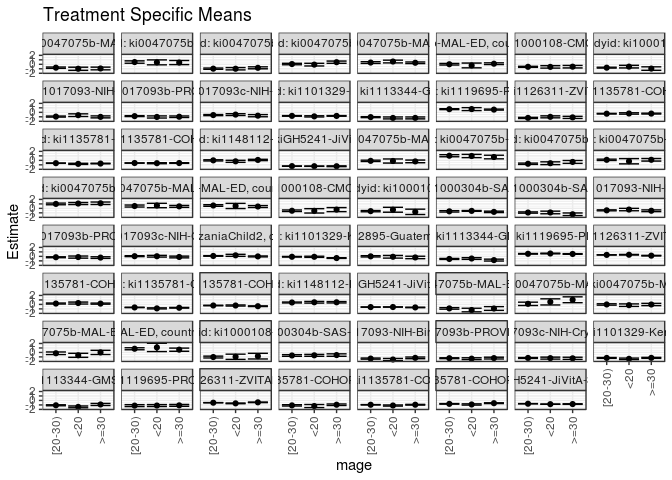

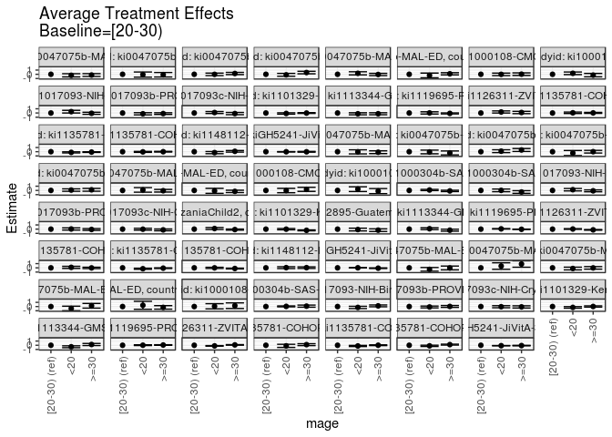

[figure not shown]

## Results Table

### Parameter: TSM

| agecat | studyid | country | intervention_level | baseline_level | estimate | ci_lower | ci_upper |
| --- | --- | --- | --- | --- | --- | --- | --- |
| Birth | ki0047075b-MAL-ED | BANGLADESH | [20-30) | NA | -0.8901171 | -1.0594711 | -0.7207631 |
| Birth | ki0047075b-MAL-ED | BANGLADESH | <20 | NA | -1.2542315 | -1.6584483 | -0.8500147 |
| Birth | ki0047075b-MAL-ED | BANGLADESH | >=30 | NA | -0.9167450 | -1.3325591 | -0.5009309 |
| Birth | ki0047075b-MAL-ED | BRAZIL | [20-30) | NA | 0.1282051 | -0.2476806 | 0.5040909 |
| Birth | ki0047075b-MAL-ED | BRAZIL | <20 | NA | 0.5562500 | -0.1284217 | 1.2409217 |
| Birth | ki0047075b-MAL-ED | BRAZIL | >=30 | NA | 1.0353333 | 0.3801713 | 1.6904954 |
| Birth | ki0047075b-MAL-ED | PERU | [20-30) | NA | -0.0115940 | -0.1688595 | 0.1456715 |
| Birth | ki0047075b-MAL-ED | PERU | <20 | NA | -0.1701788 | -0.4508017 | 0.1104441 |
| Birth | ki0047075b-MAL-ED | PERU | >=30 | NA | -0.0205021 | -0.2773156 | 0.2363113 |
| Birth | ki0047075b-MAL-ED | SOUTH AFRICA | [20-30) | NA | -0.1842935 | -0.4740092 | 0.1054222 |
| Birth | ki0047075b-MAL-ED | SOUTH AFRICA | <20 | NA | -0.6425959 | -1.0921970 | -0.1929949 |
| Birth | ki0047075b-MAL-ED | SOUTH AFRICA | >=30 | NA | 0.0020141 | -0.4656122 | 0.4696404 |
| Birth | ki0047075b-MAL-ED | TANZANIA, UNITED REPUBLIC OF | [20-30) | NA | 0.8186364 | 0.5971189 | 1.0401538 |
| Birth | ki0047075b-MAL-ED | TANZANIA, UNITED REPUBLIC OF | <20 | NA | 1.1171429 | 0.1947087 | 2.0395770 |
| Birth | ki0047075b-MAL-ED | TANZANIA, UNITED REPUBLIC OF | >=30 | NA | 0.6150000 | 0.2609657 | 0.9690343 |
| Birth | ki1000108-IRC | INDIA | [20-30) | NA | -1.0314533 | -1.2379730 | -0.8249335 |
| Birth | ki1000108-IRC | INDIA | <20 | NA | -0.9657143 | -1.5437779 | -0.3876507 |
| Birth | ki1000108-IRC | INDIA | >=30 | NA | -0.8269231 | -1.4629238 | -0.1909223 |
| Birth | ki1000304b-SAS-CompFeed | INDIA | [20-30) | NA | -0.6821767 | -0.8650806 | -0.4992728 |
| Birth | ki1000304b-SAS-CompFeed | INDIA | <20 | NA | -0.6430000 | -0.8573712 | -0.4286288 |
| Birth | ki1000304b-SAS-CompFeed | INDIA | >=30 | NA | -0.5853440 | -0.8544106 | -0.3162775 |
| Birth | ki1017093-NIH-Birth | BANGLADESH | [20-30) | NA | -1.3715992 | -1.4941715 | -1.2490269 |
| Birth | ki1017093-NIH-Birth | BANGLADESH | <20 | NA | -1.5806768 | -1.8192715 | -1.3420821 |
| Birth | ki1017093-NIH-Birth | BANGLADESH | >=30 | NA | -1.2098849 | -1.3915173 | -1.0282524 |
| Birth | ki1017093b-PROVIDE | BANGLADESH | [20-30) | NA | -1.2904818 | -1.3827984 | -1.1981653 |
| Birth | ki1017093b-PROVIDE | BANGLADESH | <20 | NA | -1.3875340 | -1.5878256 | -1.1872423 |
| Birth | ki1017093b-PROVIDE | BANGLADESH | >=30 | NA | -1.2638176 | -1.4610025 | -1.0666328 |
| Birth | ki1017093c-NIH-Crypto | BANGLADESH | [20-30) | NA | -1.2328669 | -1.3354532 | -1.1302805 |
| Birth | ki1017093c-NIH-Crypto | BANGLADESH | <20 | NA | -1.2725857 | -1.4938782 | -1.0512933 |
| Birth | ki1017093c-NIH-Crypto | BANGLADESH | >=30 | NA | -1.3130632 | -1.5491440 | -1.0769824 |

[output cut: 159 more lines]

### Parameter: E(Y)

| agecat | studyid | country | intervention_level | baseline_level | estimate | ci_lower | ci_upper |
| --- | --- | --- | --- | --- | --- | --- | --- |
| Birth | ki0047075b-MAL-ED | BANGLADESH | NA | NA | -0.9418605 | -1.0869834 | -0.7967375 |
| Birth | ki0047075b-MAL-ED | BRAZIL | NA | NA | 0.4029032 | 0.0896793 | 0.7161272 |
| Birth | ki0047075b-MAL-ED | PERU | NA | NA | -0.0520175 | -0.1725298 | 0.0684947 |
| Birth | ki0047075b-MAL-ED | SOUTH AFRICA | NA | NA | -0.1925833 | -0.4053570 | 0.0201904 |
| Birth | ki0047075b-MAL-ED | TANZANIA, UNITED REPUBLIC OF | NA | NA | 0.7624348 | 0.5710709 | 0.9537986 |
| Birth | ki1000108-IRC | INDIA | NA | NA | -1.0105831 | -1.1973019 | -0.8238643 |
| Birth | ki1000304b-SAS-CompFeed | INDIA | NA | NA | -0.6700453 | -0.8474950 | -0.4925957 |
| Birth | ki1017093-NIH-Birth | BANGLADESH | NA | NA | -1.3545637 | -1.4492090 | -1.2599184 |
| Birth | ki1017093b-PROVIDE | BANGLADESH | NA | NA | -1.2984586 | -1.3752758 | -1.2216415 |
| Birth | ki1017093c-NIH-Crypto | BANGLADESH | NA | NA | -1.2441513 | -1.3281130 | -1.1601897 |
| Birth | ki1101329-Keneba | GAMBIA | NA | NA | -1.2349454 | -1.2972413 | -1.1726496 |
| Birth | ki1113344-GMS-Nepal | NEPAL | NA | NA | -1.1164431 | -1.2040134 | -1.0288728 |
| Birth | ki1119695-PROBIT | BELARUS | NA | NA | -1.1448633 | -1.3544229 | -0.9353037 |
| Birth | ki1126311-ZVITAMBO | ZIMBABWE | NA | NA | -0.5144298 | -0.5403185 | -0.4885410 |
| Birth | ki1135781-COHORTS | GUATEMALA | NA | NA | -1.0621429 | -1.1631387 | -0.9611471 |
| Birth | ki1135781-COHORTS | INDIA | NA | NA | -0.9742815 | -1.0093427 | -0.9392203 |
| Birth | ki1135781-COHORTS | PHILIPPINES | NA | NA | -0.7427251 | -0.7890855 | -0.6963647 |
| Birth | kiGH5241-JiVitA-3 | BANGLADESH | NA | NA | -0.7777196 | -0.7967334 | -0.7587059 |
| 6 months | ki0047075b-MAL-ED | BANGLADESH | NA | NA | -0.1376763 | -0.2664642 | -0.0088885 |
| 6 months | ki0047075b-MAL-ED | BRAZIL | NA | NA | 0.9720774 | 0.8078144 | 1.1363403 |
| 6 months | ki0047075b-MAL-ED | INDIA | NA | NA | -0.7077885 | -0.8346769 | -0.5809000 |
| 6 months | ki0047075b-MAL-ED | NEPAL | NA | NA | 0.1104308 | -0.0208643 | 0.2417259 |
| 6 months | ki0047075b-MAL-ED | PERU | NA | NA | 1.0528816 | 0.9313005 | 1.1744626 |
| 6 months | ki0047075b-MAL-ED | SOUTH AFRICA | NA | NA | 0.5421785 | 0.3900443 | 0.6943126 |
| 6 months | ki0047075b-MAL-ED | TANZANIA, UNITED REPUBLIC OF | NA | NA | 0.5362213 | 0.4049390 | 0.6675036 |
| 6 months | ki1000108-CMC-V-BCS-2002 | INDIA | NA | NA | -0.5026766 | -0.6536848 | -0.3516685 |
| 6 months | ki1000108-IRC | INDIA | NA | NA | -0.5989297 | -0.7344491 | -0.4634104 |
| 6 months | ki1000304b-SAS-CompFeed | INDIA | NA | NA | -0.6657084 | -0.8024377 | -0.5289791 |
| 6 months | ki1000304b-SAS-FoodSuppl | INDIA | NA | NA | -1.0121579 | -1.1280429 | -0.8962729 |
| 6 months | ki1017093-NIH-Birth | BANGLADESH | NA | NA | -0.4495343 | -0.5402027 | -0.3588659 |
| 6 months | ki1017093b-PROVIDE | BANGLADESH | NA | NA | -0.1990907 | -0.2817968 | -0.1163845 |
| 6 months | ki1017093c-NIH-Crypto | BANGLADESH | NA | NA | 0.0297622 | -0.0491685 | 0.1086930 |
| 6 months | ki1066203-TanzaniaChild2 | TANZANIA, UNITED REPUBLIC OF | NA | NA | 0.0782666 | 0.0252568 | 0.1312764 |
| 6 months | ki1101329-Keneba | GAMBIA | NA | NA | -0.1833609 | -0.2343611 | -0.1323607 |
| 6 months | ki1112895-Guatemala BSC | GUATEMALA | NA | NA | -0.0619988 | -0.1773839 | 0.0533863 |
| 6 months | ki1113344-GMS-Nepal | NEPAL | NA | NA | -0.6038416 | -0.6899448 | -0.5177384 |
| 6 months | ki1119695-PROBIT | BELARUS | NA | NA | 0.5792439 | 0.5193388 | 0.6391490 |
| 6 months | ki1126311-ZVITAMBO | ZIMBABWE | NA | NA | 0.3103322 | 0.2846161 | 0.3360483 |
| 6 months | ki1135781-COHORTS | GUATEMALA | NA | NA | 0.1940810 | 0.1226351 | 0.2655269 |
| 6 months | ki1135781-COHORTS | INDIA | NA | NA | -0.7119298 | -0.7444861 | -0.6793734 |
| 6 months | ki1135781-COHORTS | PHILIPPINES | NA | NA | -0.2938433 | -0.3352064 | -0.2524802 |
| 6 months | ki1148112-LCNI-5 | MALAWI | NA | NA | 0.4409268 | 0.3613957 | 0.5204578 |
| 6 months | kiGH5241-JiVitA-3 | BANGLADESH | NA | NA | -0.5933575 | -0.6128938 | -0.5738211 |
| 24 months | ki0047075b-MAL-ED | BANGLADESH | NA | NA | -0.8192925 | -0.9412667 | -0.6973182 |
| 24 months | ki0047075b-MAL-ED | BRAZIL | NA | NA | 0.4626233 | 0.2567495 | 0.6684971 |
| 24 months | ki0047075b-MAL-ED | INDIA | NA | NA | -0.9564667 | -1.0725632 | -0.8403701 |
| 24 months | ki0047075b-MAL-ED | PERU | NA | NA | 0.1111982 | -0.0118399 | 0.2342362 |
| 24 months | ki0047075b-MAL-ED | SOUTH AFRICA | NA | NA | 0.4090301 | 0.2879441 | 0.5301161 |
| 24 months | ki0047075b-MAL-ED | TANZANIA, UNITED REPUBLIC OF | NA | NA | 0.0547975 | -0.0703378 | 0.1799328 |
| 24 months | ki1000108-CMC-V-BCS-2002 | INDIA | NA | NA | -0.5571505 | -0.6585247 | -0.4557763 |
| 24 months | ki1000108-IRC | INDIA | NA | NA | -0.7458150 | -0.8368180 | -0.6548120 |
| 24 months | ki1017093-NIH-Birth | BANGLADESH | NA | NA | -0.9097790 | -1.0080462 | -0.8115117 |
| 24 months | ki1017093b-PROVIDE | BANGLADESH | NA | NA | -0.8928670 | -0.9755153 | -0.8102187 |
| 24 months | ki1017093c-NIH-Crypto | BANGLADESH | NA | NA | -0.6103502 | -0.7050157 | -0.5156847 |
| 24 months | ki1101329-Keneba | GAMBIA | NA | NA | -0.8079199 | -0.8550714 | -0.7607684 |
| 24 months | ki1113344-GMS-Nepal | NEPAL | NA | NA | -1.1363107 | -1.2252817 | -1.0473398 |
| 24 months | ki1119695-PROBIT | BELARUS | NA | NA | 0.6874295 | 0.5756922 | 0.7991668 |
| 24 months | ki1126311-ZVITAMBO | ZIMBABWE | NA | NA | -1.1845602 | -1.2836321 | -1.0854883 |
| 24 months | ki1135781-COHORTS | GUATEMALA | NA | NA | -0.2813755 | -0.3354674 | -0.2272835 |
| 24 months | ki1135781-COHORTS | INDIA | NA | NA | -0.6627749 | -0.6962103 | -0.6293395 |
| 24 months | ki1135781-COHORTS | PHILIPPINES | NA | NA | -0.6099592 | -0.6467541 | -0.5731643 |
| 24 months | ki1148112-LCNI-5 | MALAWI | NA | NA | -0.0115944 | -0.1019822 | 0.0787935 |
| 24 months | kiGH5241-JiVitA-3 | BANGLADESH | NA | NA | -1.2977181 | -1.3209986 | -1.2744376 |

### Parameter: ATE

| agecat | studyid | country | intervention_level | baseline_level | estimate | ci_lower | ci_upper |
| --- | --- | --- | --- | --- | --- | --- | --- |
| Birth | ki0047075b-MAL-ED | BANGLADESH | [20-30) | [20-30) | 0.0000000 | 0.0000000 | 0.0000000 |
| Birth | ki0047075b-MAL-ED | BANGLADESH | <20 | [20-30) | -0.3641144 | -0.8042567 | 0.0760279 |
| Birth | ki0047075b-MAL-ED | BANGLADESH | >=30 | [20-30) | -0.0266279 | -0.4759008 | 0.4226450 |
| Birth | ki0047075b-MAL-ED | BRAZIL | [20-30) | [20-30) | 0.0000000 | 0.0000000 | 0.0000000 |
| Birth | ki0047075b-MAL-ED | BRAZIL | <20 | [20-30) | 0.4280449 | -0.3530220 | 1.2091117 |
| Birth | ki0047075b-MAL-ED | BRAZIL | >=30 | [20-30) | 0.9071282 | 0.1517955 | 1.6624609 |
| Birth | ki0047075b-MAL-ED | PERU | [20-30) | [20-30) | 0.0000000 | 0.0000000 | 0.0000000 |
| Birth | ki0047075b-MAL-ED | PERU | <20 | [20-30) | -0.1585848 | -0.4816602 | 0.1644906 |
| Birth | ki0047075b-MAL-ED | PERU | >=30 | [20-30) | -0.0089081 | -0.3092058 | 0.2913896 |
| Birth | ki0047075b-MAL-ED | SOUTH AFRICA | [20-30) | [20-30) | 0.0000000 | 0.0000000 | 0.0000000 |
| Birth | ki0047075b-MAL-ED | SOUTH AFRICA | <20 | [20-30) | -0.4583025 | -0.9995912 | 0.0829862 |
| Birth | ki0047075b-MAL-ED | SOUTH AFRICA | >=30 | [20-30) | 0.1863075 | -0.3690554 | 0.7416704 |
| Birth | ki0047075b-MAL-ED | TANZANIA, UNITED REPUBLIC OF | [20-30) | [20-30) | 0.0000000 | 0.0000000 | 0.0000000 |
| Birth | ki0047075b-MAL-ED | TANZANIA, UNITED REPUBLIC OF | <20 | [20-30) | 0.2985065 | -0.6501530 | 1.2471660 |
| Birth | ki0047075b-MAL-ED | TANZANIA, UNITED REPUBLIC OF | >=30 | [20-30) | -0.2036364 | -0.6212610 | 0.2139882 |
| Birth | ki1000108-IRC | INDIA | [20-30) | [20-30) | 0.0000000 | 0.0000000 | 0.0000000 |
| Birth | ki1000108-IRC | INDIA | <20 | [20-30) | 0.0657390 | -0.5481078 | 0.6795858 |
| Birth | ki1000108-IRC | INDIA | >=30 | [20-30) | 0.2045302 | -0.4641606 | 0.8732210 |
| Birth | ki1000304b-SAS-CompFeed | INDIA | [20-30) | [20-30) | 0.0000000 | 0.0000000 | 0.0000000 |
| Birth | ki1000304b-SAS-CompFeed | INDIA | <20 | [20-30) | 0.0391766 | -0.0619100 | 0.1402633 |
| Birth | ki1000304b-SAS-CompFeed | INDIA | >=30 | [20-30) | 0.0968327 | -0.1564583 | 0.3501236 |
| Birth | ki1017093-NIH-Birth | BANGLADESH | [20-30) | [20-30) | 0.0000000 | 0.0000000 | 0.0000000 |
| Birth | ki1017093-NIH-Birth | BANGLADESH | <20 | [20-30) | -0.2090776 | -0.4770476 | 0.0588924 |
| Birth | ki1017093-NIH-Birth | BANGLADESH | >=30 | [20-30) | 0.1617143 | -0.0579520 | 0.3813807 |
| Birth | ki1017093b-PROVIDE | BANGLADESH | [20-30) | [20-30) | 0.0000000 | 0.0000000 | 0.0000000 |
| Birth | ki1017093b-PROVIDE | BANGLADESH | <20 | [20-30) | -0.0970521 | -0.3178928 | 0.1237886 |
| Birth | ki1017093b-PROVIDE | BANGLADESH | >=30 | [20-30) | 0.0266642 | -0.1910084 | 0.2443369 |
| Birth | ki1017093c-NIH-Crypto | BANGLADESH | [20-30) | [20-30) | 0.0000000 | 0.0000000 | 0.0000000 |
| Birth | ki1017093c-NIH-Crypto | BANGLADESH | <20 | [20-30) | -0.0397189 | -0.2838119 | 0.2043741 |
| Birth | ki1017093c-NIH-Crypto | BANGLADESH | >=30 | [20-30) | -0.0801963 | -0.3387692 | 0.1783766 |

[output cut: 159 more lines]

### Parameter: PAR

| agecat | studyid | country | intervention_level | baseline_level | estimate | ci_lower | ci_upper |
| --- | --- | --- | --- | --- | --- | --- | --- |
| Birth | ki0047075b-MAL-ED | BANGLADESH | [20-30) | NA | -0.0517434 | -0.1550760 | 0.0515893 |
| Birth | ki0047075b-MAL-ED | BRAZIL | [20-30) | NA | 0.2746981 | 0.0264094 | 0.5229868 |
| Birth | ki0047075b-MAL-ED | PERU | [20-30) | NA | -0.0404235 | -0.1623209 | 0.0814739 |
| Birth | ki0047075b-MAL-ED | SOUTH AFRICA | [20-30) | NA | -0.0082899 | -0.2143066 | 0.1977269 |
| Birth | ki0047075b-MAL-ED | TANZANIA, UNITED REPUBLIC OF | [20-30) | NA | -0.0562016 | -0.2275676 | 0.1151644 |
| Birth | ki1000108-IRC | INDIA | [20-30) | NA | 0.0208702 | -0.0542483 | 0.0959887 |
| Birth | ki1000304b-SAS-CompFeed | INDIA | [20-30) | NA | 0.0121314 | -0.0242405 | 0.0485032 |
| Birth | ki1017093-NIH-Birth | BANGLADESH | [20-30) | NA | 0.0170355 | -0.0450959 | 0.0791669 |
| Birth | ki1017093b-PROVIDE | BANGLADESH | [20-30) | NA | -0.0079768 | -0.0600935 | 0.0441399 |
| Birth | ki1017093c-NIH-Crypto | BANGLADESH | [20-30) | NA | -0.0112845 | -0.0735057 | 0.0509368 |
| Birth | ki1101329-Keneba | GAMBIA | [20-30) | NA | -0.0042708 | -0.0739677 | 0.0654261 |
| Birth | ki1113344-GMS-Nepal | NEPAL | [20-30) | NA | -0.0370160 | -0.1011663 | 0.0271343 |
| Birth | ki1119695-PROBIT | BELARUS | [20-30) | NA | 0.0113555 | -0.0059657 | 0.0286768 |
| Birth | ki1126311-ZVITAMBO | ZIMBABWE | [20-30) | NA | -0.0103583 | -0.0286297 | 0.0079131 |
| Birth | ki1135781-COHORTS | GUATEMALA | [20-30) | NA | 0.0394427 | -0.0700031 | 0.1488884 |
| Birth | ki1135781-COHORTS | INDIA | [20-30) | NA | -0.0103176 | -0.0354272 | 0.0147920 |
| Birth | ki1135781-COHORTS | PHILIPPINES | [20-30) | NA | 0.0212038 | -0.0168459 | 0.0592536 |
| Birth | kiGH5241-JiVitA-3 | BANGLADESH | [20-30) | NA | -0.0478786 | -0.0637581 | -0.0319990 |
| 6 months | ki0047075b-MAL-ED | BANGLADESH | [20-30) | NA | -0.0252649 | -0.1131265 | 0.0625967 |
| 6 months | ki0047075b-MAL-ED | BRAZIL | [20-30) | NA | -0.0588138 | -0.2055939 | 0.0879664 |
| 6 months | ki0047075b-MAL-ED | INDIA | [20-30) | NA | 0.0542103 | -0.0092145 | 0.1176351 |
| 6 months | ki0047075b-MAL-ED | NEPAL | [20-30) | NA | -0.0058125 | -0.0715975 | 0.0599726 |
| 6 months | ki0047075b-MAL-ED | PERU | [20-30) | NA | 0.0606661 | -0.0691233 | 0.1904554 |
| 6 months | ki0047075b-MAL-ED | SOUTH AFRICA | [20-30) | NA | 0.0238688 | -0.1383880 | 0.1861256 |
| 6 months | ki0047075b-MAL-ED | TANZANIA, UNITED REPUBLIC OF | [20-30) | NA | -0.1037559 | -0.2317831 | 0.0242714 |
| 6 months | ki1000108-CMC-V-BCS-2002 | INDIA | [20-30) | NA | 0.0276202 | -0.0496471 | 0.1048875 |
| 6 months | ki1000108-IRC | INDIA | [20-30) | NA | 0.0163578 | -0.0532078 | 0.0859233 |
| 6 months | ki1000304b-SAS-CompFeed | INDIA | [20-30) | NA | -0.0017052 | -0.0324747 | 0.0290644 |
| 6 months | ki1000304b-SAS-FoodSuppl | INDIA | [20-30) | NA | -0.0814824 | -0.1638615 | 0.0008966 |
| 6 months | ki1017093-NIH-Birth | BANGLADESH | [20-30) | NA | -0.0109420 | -0.0745824 | 0.0526984 |
| 6 months | ki1017093b-PROVIDE | BANGLADESH | [20-30) | NA | -0.0087301 | -0.0604153 | 0.0429552 |
| 6 months | ki1017093c-NIH-Crypto | BANGLADESH | [20-30) | NA | -0.0168044 | -0.0757575 | 0.0421486 |
| 6 months | ki1066203-TanzaniaChild2 | TANZANIA, UNITED REPUBLIC OF | [20-30) | NA | -0.0178261 | -0.0581072 | 0.0224550 |
| 6 months | ki1101329-Keneba | GAMBIA | [20-30) | NA | -0.0974093 | -0.1519301 | -0.0428884 |
| 6 months | ki1112895-Guatemala BSC | GUATEMALA | [20-30) | NA | -0.0693442 | -0.1634795 | 0.0247912 |
| 6 months | ki1113344-GMS-Nepal | NEPAL | [20-30) | NA | -0.0295587 | -0.0902404 | 0.0311231 |
| 6 months | ki1119695-PROBIT | BELARUS | [20-30) | NA | 0.0019225 | -0.0090593 | 0.0129043 |
| 6 months | ki1126311-ZVITAMBO | ZIMBABWE | [20-30) | NA | -0.0243775 | -0.0429307 | -0.0058242 |
| 6 months | ki1135781-COHORTS | GUATEMALA | [20-30) | NA | 0.0034083 | -0.0746124 | 0.0814290 |
| 6 months | ki1135781-COHORTS | INDIA | [20-30) | NA | -0.0355702 | -0.0581499 | -0.0129906 |
| 6 months | ki1135781-COHORTS | PHILIPPINES | [20-30) | NA | -0.0515946 | -0.0867538 | -0.0164354 |
| 6 months | ki1148112-LCNI-5 | MALAWI | [20-30) | NA | 0.0146823 | -0.0590696 | 0.0884342 |
| 6 months | kiGH5241-JiVitA-3 | BANGLADESH | [20-30) | NA | 0.0002801 | -0.0185503 | 0.0191105 |
| 24 months | ki0047075b-MAL-ED | BANGLADESH | [20-30) | NA | -0.0667314 | -0.1480685 | 0.0146056 |
| 24 months | ki0047075b-MAL-ED | BRAZIL | [20-30) | NA | -0.0392727 | -0.2150178 | 0.1364724 |
| 24 months | ki0047075b-MAL-ED | INDIA | [20-30) | NA | 0.0166992 | -0.0374871 | 0.0708855 |
| 24 months | ki0047075b-MAL-ED | PERU | [20-30) | NA | 0.0527473 | -0.0791471 | 0.1846417 |
| 24 months | ki0047075b-MAL-ED | SOUTH AFRICA | [20-30) | NA | 0.0186727 | -0.1225700 | 0.1599154 |
| 24 months | ki0047075b-MAL-ED | TANZANIA, UNITED REPUBLIC OF | [20-30) | NA | 0.0400925 | -0.0781403 | 0.1583253 |
| 24 months | ki1000108-CMC-V-BCS-2002 | INDIA | [20-30) | NA | 0.0017628 | -0.0449995 | 0.0485250 |
| 24 months | ki1000108-IRC | INDIA | [20-30) | NA | 0.0069158 | -0.0351308 | 0.0489624 |
| 24 months | ki1017093-NIH-Birth | BANGLADESH | [20-30) | NA | 0.0414305 | -0.0284189 | 0.1112799 |
| 24 months | ki1017093b-PROVIDE | BANGLADESH | [20-30) | NA | -0.0451249 | -0.0955368 | 0.0052870 |
| 24 months | ki1017093c-NIH-Crypto | BANGLADESH | [20-30) | NA | 0.0032500 | -0.0640192 | 0.0705192 |
| 24 months | ki1101329-Keneba | GAMBIA | [20-30) | NA | -0.0158534 | -0.0683974 | 0.0366906 |
| 24 months | ki1113344-GMS-Nepal | NEPAL | [20-30) | NA | -0.0686646 | -0.1341138 | -0.0032154 |
| 24 months | ki1119695-PROBIT | BELARUS | [20-30) | NA | -0.0141786 | -0.0563155 | 0.0279583 |
| 24 months | ki1126311-ZVITAMBO | ZIMBABWE | [20-30) | NA | 0.0623174 | -0.0119083 | 0.1365430 |
| 24 months | ki1135781-COHORTS | GUATEMALA | [20-30) | NA | 0.0239336 | -0.0323861 | 0.0802532 |
| 24 months | ki1135781-COHORTS | INDIA | [20-30) | NA | -0.0331995 | -0.0565713 | -0.0098278 |
| 24 months | ki1135781-COHORTS | PHILIPPINES | [20-30) | NA | -0.0118146 | -0.0422435 | 0.0186143 |
| 24 months | ki1148112-LCNI-5 | MALAWI | [20-30) | NA | -0.0094515 | -0.0942249 | 0.0753219 |
| 24 months | kiGH5241-JiVitA-3 | BANGLADESH | [20-30) | NA | -0.0099005 | -0.0333422 | 0.0135412 |